# PSTAT131 Final Project

Ying Zhou

12/1/2022

# Introduction

The purpose of the project is to generate a model that predict the potential YouTube views for the video of Stray Kids.

# Who is Stray Kids?

Stray Kids is a South Korean boy band formed by JYP Entertainment through the 2017 reality show of the same name. The group is composed of eight members: Bang Chan, Lee Know, Changbin, Hyunjin, Han, Felix, Seungmin, and I.N. According to Bang Chan, the leader of the band, their goal is to deliver their music and give strength to people who really need it. Stray Kids’ music is generally K-pop, hip hop, and electronic. And they can also be considered as a self-producing band, with members involved in songwriting and composing, and arranging. After debut in 2017, their popularity continues to rise. In 2022, they started their second world tour. On April 20, 2022, they notched their first chart-topper on Billboard 200 album chart, with their EP “ODDINARY”. On October 16, they topped the Billboard 200 again with their new EP “MAXIDENT”.

# Why might this model be useful?

In such an era of rapid Internet growth, people are building their influence, income and impact through YouTube. For Korean group, YouTube is a good platform to promote and publicize their works. Since it is a worldwide platform, uploading videos on YouTube helps to promote the K-pop culture to people around the world who are interested in it. How do we see the influence of a group? The views of the video is considered as an important factor to reflect the popularity. This model will predict the future views of the music video based on the data collected and thus help analyzing the popularity to look into the future development of the band.

Here are some examples of Stray Kids’ music videos:

```r
library(vembedr)
# "Case 143" (Lead single of album "MAXIDENT")
embed_youtube("jYSlpC6Ud2A")
```

[interactive chart not shown]

```r
# "Thunderous" (Lead single of album "NOEASY")
embed_youtube("EaswWiwMVs8")
```

[interactive chart not shown]

```r
# "Venom" (side track of album "Oddinary")
embed_youtube("pM-jOfy_1jM")
```

[interactive chart not shown]

# Loading Data and Packages

This project uses the YouTube API for data scraping, which contains information of all videos posted on YouTube. For convenience, I use the tuber package in R by Gaurav Sood that based on the YouTube data API.

The full codebook is in my files. Here are some important variables of this report:

- view count
- like count
- comment count

```r
# loading packages
library(tidyverse)
library(lubridate)
library(tidymodels)
library(skimr)
library(patchwork)
library(janitor)
library(parsedate)
library(dbplyr)
library(corrplot)
library(pheatmap)
library(caret)
library(pROC)
```

# Exploratory data analysis

```r
# reading data
channel<- read.csv(file = "/Users/yzhou/PSTAT131/final project/skz_channel_data.csv")
playlist<- read.csv(file = "/Users/yzhou/PSTAT131/final project/skz_all_playlist_data.csv")
trainskz<- read.csv(file = "/Users/yzhou/PSTAT131/final project/skz_all_videos_raw_data.csv")
```

## Data Cleaning

The collected data was already pretty tidy, but we can do few steps to make it tidier for easier work later.

```r
# clean names
trainskz <- trainskz %>%
  clean_names()
```

```r
# remove unimportant variables
trainskz <- trainskz %>%
  select(-description, -title, -channel_id, -favorite_count, -url, -channel_title)
```

I remove favorite count here because it is 0 for all the videos so it is meaningless to include it.

```r
# create date into lubridate format
trainskz <- trainskz %>%
  mutate(
    date = parse_date(publication_date),
    date_wo_time = format(as.POSIXct(date,
                  format = '%m/%d/%Y %H:%M:%S'),
       format = '%Y/%m/%d'),
    year = year(date)
  )
```

```r
# remove the live video with 0 view and remove rows with NA
trainskz <- trainskz %>%
  filter(view_count != 0) %>%
  drop_na()
```

Show the data and the demension.

```r
# show the data
trainskz %>%
  head()
```

```
##            id     publication_date view_count like_count comment_count
## 1 _1S6lmft6I8 2018-11-03T12:01:10Z     518376      41694           801
## 2 _8yW_GC40-w 2021-07-05T10:59:57Z    1231218     289624         12725
## 3 _HclYiIuxUk 2021-07-28T10:59:57Z    1878916     194551          6879
## 4 _Lo6_GNtBa4 2020-01-08T12:59:58Z    1206863      93854          1983
## 5 _mR4IgEjM48 2018-07-17T09:26:37Z     245055      30892          1131
## 6 _oCptmj2gIQ 2020-05-16T14:59:53Z    8118563     515723         44005
##                  date date_wo_time year
## 1 2018-11-03 12:01:10   2018/11/03 2018
## 2 2021-07-05 10:59:57   2021/07/05 2021
## 3 2021-07-28 10:59:57   2021/07/28 2021
## 4 2020-01-08 12:59:58   2020/01/08 2020
## 5 2018-07-17 09:26:37   2018/07/17 2018
## 6 2020-05-16 14:59:53   2020/05/16 2020
```

```r
# data size
dim(trainskz)
```

```
## [1] 680   8
```

The data set contains 680 observations.

## EDA

```r
# mean, standard deviation, median, min and max
summary(trainskz)
```

```
##       id            publication_date     view_count         like_count
##  Length:680         Length:680         Min.   :   99473   Min.   :  13550
##  Class :character   Class :character   1st Qu.:  511038   1st Qu.:  63243
##  Mode  :character   Mode  :character   Median :  914961   Median : 117658
##                                        Mean   : 2676941   Mean   : 205483
##                                        3rd Qu.: 2135619   3rd Qu.: 236656
##                                        Max.   :64392799   Max.   :2433392
##  comment_count         date                     date_wo_time
##  Min.   :     0   Min.   :2018-01-05 10:27:29   Length:680
##  1st Qu.:  1536   1st Qu.:2019-04-01 18:00:07   Class :character
##  Median :  3092   Median :2020-08-26 22:15:23   Mode  :character
##  Mean   :  7625   Mean   :2020-07-23 15:45:08
##  3rd Qu.:  7078   3rd Qu.:2021-10-25 04:59:56
##  Max.   :186105   Max.   :2022-12-04 07:24:25
##       year
##  Min.   :2018
##  1st Qu.:2019
##  Median :2020
##  Mean   :2020
##  3rd Qu.:2021
##  Max.   :2022
```

We can compare the ratio of view count and like count, and view count and comment count.

```r
# ratio of view count and like count
ratio_view_like<- trainskz$view_count/trainskz$like_count
max(ratio_view_like)
```

```
## [1] 34.64865
```

```r
min(ratio_view_like)
```

```
## [1] 3.02351
```

```r
# ratio of view count and comment count
ratio_view_comment<- trainskz$view_count/trainskz$comment_count
max(ratio_view_comment)
```

```
## [1] Inf
```

```r
min(ratio_view_comment)
```

```
## [1] 38.59635
```

We can find that views are much more than comments and likes.

Create a box plot to see the distribution of the data.

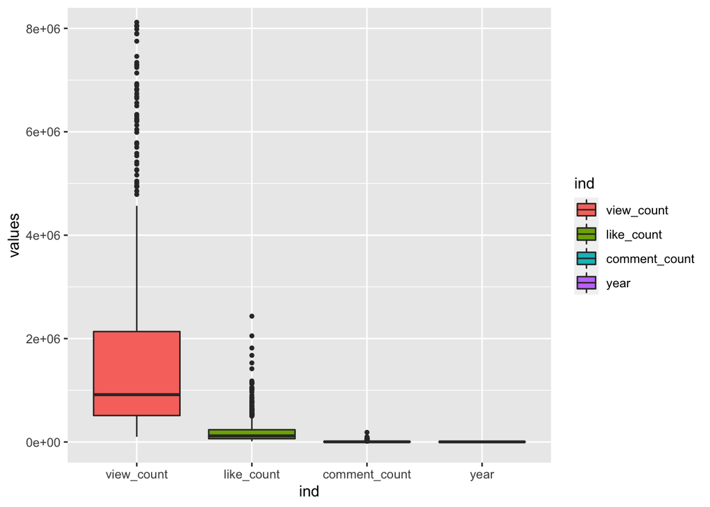

```r
skz_features <- trainskz %>%
  select(view_count,like_count,comment_count,year)
stack_skz_features <- stack(skz_features)
ggplot(stack_skz_features, aes(x=ind, y=values,fill=ind)) +
  geom_boxplot(outlier.size = 1)+
  coord_cartesian(ylim = c(0, 8000000))
```

We can discover that these features (view count,like count,comment count) have many outliers, especially view count. Thus, we need to use logarithmic transformations for these features.

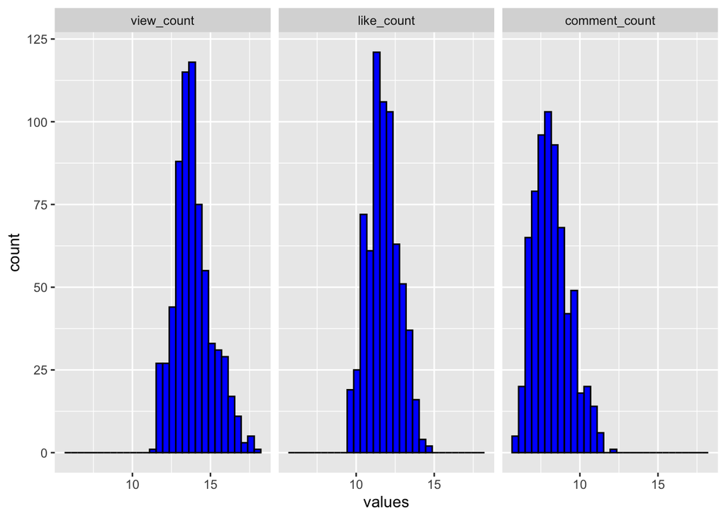

```r
# logarithmic transformations
features_2 <- select(skz_features,-year)
log_features <- log(features_2) %>%
  stack() %>%
  filter_all(all_vars(!is.infinite(.)))
# visualize data distribution
# histogram
log_features %>%
  ggplot(aes(x=values)) +
  geom_histogram(bins = 30, colour = "black", fill = "blue") +
  facet_wrap(~ ind)
```

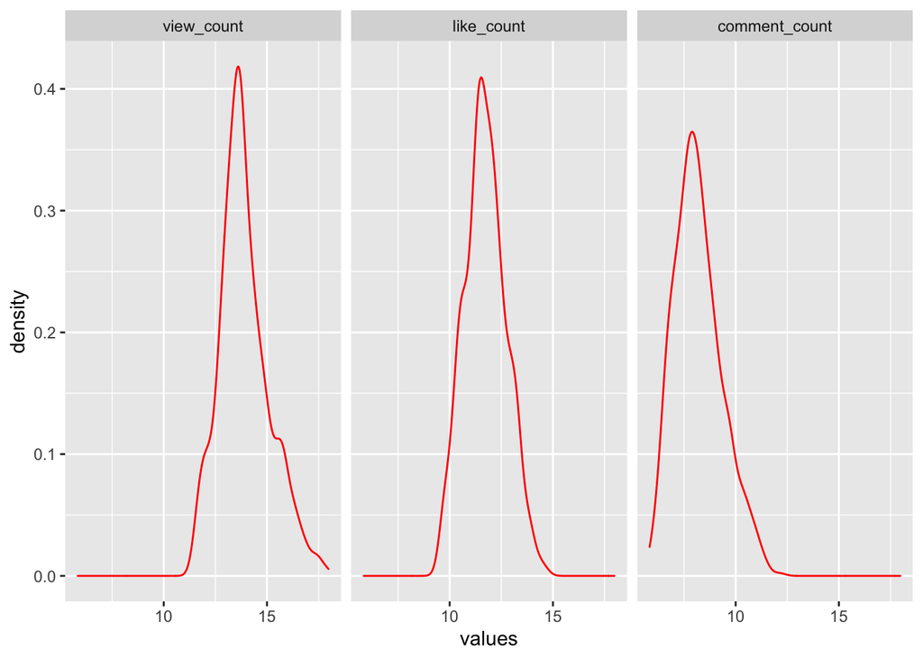

```r
# density curve
log_features %>%
  ggplot(aes(x=values)) +
  geom_density(color="red",alpha=0.8)+
  facet_wrap(~ ind)
```

We can find that the view count and the comment count is positively skewed and the like count is slight positively(right) skewed.

The we create a correlation matrix and a heat map.

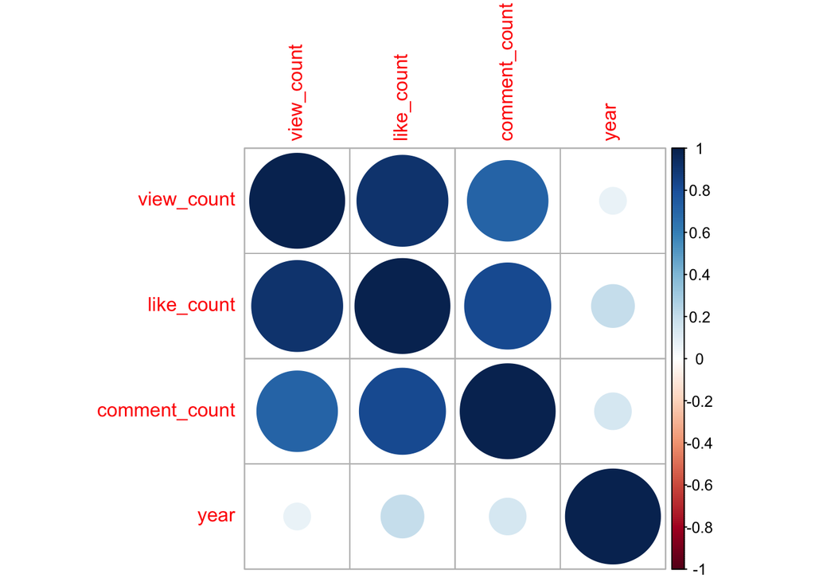

```r
# create a correlation matrix for these features
cor_features <- cor(skz_features)
corrplot(cor_features)
```

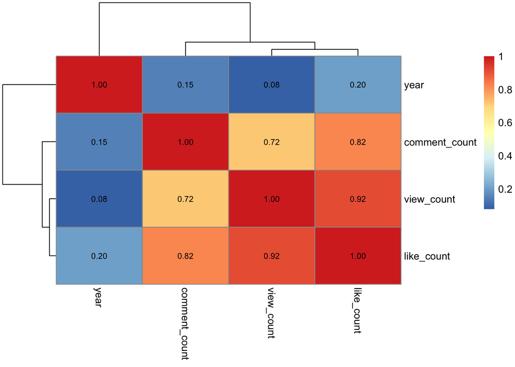

```r
# create a heat map
pheatmap(cor_features,
         display_numbers = TRUE,
         number_color = "black",
         fontsize_number = 8)
```

From the matrix and the heatmap we can find that there are 2 features that have a strong positive correlation to views, namely the like count, and the comment_count. Larger values show stronger correlation.